# Analisis de Muchos Modelos

Sebastian Jaremczuk

2020-04-17

```r
# para que los widget los tome como printscreen cdo hace df
# install.packages("webshot")
# webshot::install_phantomjs()
```

### 0.0.1 carga de datos

```r
datos_train_prep = read_rds(path = paste0(path_base, config$outputs, "baseline_2009_train_prep.rds") )
datos_test_prep = read_rds(path = paste0(path_base, config$outputs, "baseline_2009_test_prep.rds") )
```

```r
modelo_knn = read_rds(path = paste0(path_base, config$outputs, "modelo_knn.rds") )
modelo_nb = read_rds(path = paste0(path_base, config$outputs, "modelo_nb.rds") )
modelo_logistic = read_rds(path = paste0(path_base, config$outputs, "modelo_logistic.rds") )
modelo_lda = read_rds(path = paste0(path_base, config$outputs, "modelo_lda.rds") )
modelo_C50Tree = read_rds(path = paste0(path_base, config$outputs, "modelo_C50Tree.rds") )
modelo_rf = read_rds(path = paste0(path_base, config$outputs, "modelo_rf.rds") )
modelo_boost = read_rds(path = paste0(path_base, config$outputs, "modelo_boost.rds") )
modelo_svmrad = read_rds(path = paste0(path_base, config$outputs, "modelo_svmrad.rds") )
modelo_nnet = read_rds(path = paste0(path_base, config$outputs, "modelo_nnet.rds") )
```

```r
paste0(path_base,config$outputs, ArchivoDeSalidaRDS)
```

```
[1] "/home/rstudio/desercion/outputs/00_modelo_02/modelos_reglog_svm_rf_datos01.rds"
```

```r
grid_modelos_sinCicloLectivo_knn_gbm = read_rds(path = paste0(path_base,config$outputs, "modelos_reglog_svm_rf_datos03.rds"))
```

[output not shown]

```r
modelos <- list(KNN = modelo_knn, logistic = modelo_logistic,
                LDA = modelo_lda, rf = modelo_rf, arbol = modelo_C50Tree,
                boosting = modelo_boost, SVMradial = modelo_svmrad)

#  NB = modelo_nb,
```

[output not shown]

# 1 KNN

## 1.1 Modelar

El modelo obtenido durante el entrenamiento es el siguiente:

| k | Accuracy | Kappa | AccuracySD | KappaSD |
| --- | --- | --- | --- | --- |
| 1 | 0.7583203 | 0.5077784 | 0.0218490 | 0.0451777 |
| 2 | 0.7535556 | 0.4981009 | 0.0216224 | 0.0439617 |
| 5 | 0.7956132 | 0.5810591 | 0.0202191 | 0.0417847 |
| 10 | 0.7993774 | 0.5877563 | 0.0228967 | 0.0477935 |
| 15 | 0.8021971 | 0.5937258 | 0.0229241 | 0.0476222 |
| 20 | 0.8033252 | 0.5959767 | 0.0204760 | 0.0428055 |
| 30 | 0.8049545 | 0.5995533 | 0.0209553 | 0.0434628 |
| 50 | 0.8124159 | 0.6144606 | 0.0209855 | 0.0437144 |
| 60 | 0.8122281 | 0.6140509 | 0.0206854 | 0.0430537 |
| 70 | 0.8127294 | 0.6149712 | 0.0209825 | 0.0437856 |
| 80 | 0.8096591 | 0.6085439 | 0.0224092 | 0.0466400 |

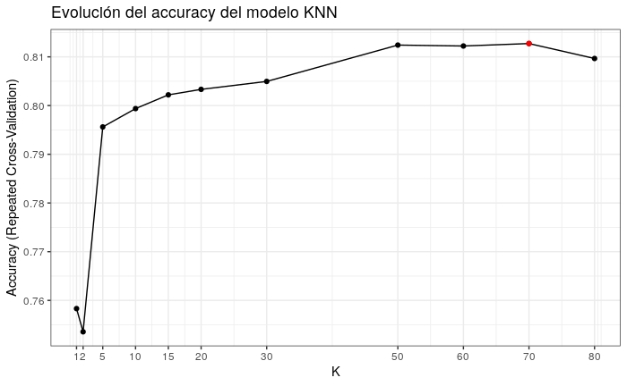

Se puede decir que el mejor modelo obtenido en la etapa de entrenamiento es con k = 70 con un accuracy promedio de 81,27 %

## 1.2 describir el modelo

El modelo de knn entrenado aporta un buen porcentaje de aciertos que supera ampliamente el nivel mínimo que corresponde a la clase mayoritaria. Sin embargo, una mejor manera de avaluarlo es utilizando el conjunto de test cuyas observaciones no han sido utilizadas hasta ahora.

```r
metodo = "KNN"

cf = confusionMatrix(data = predicciones %>% filter(object == "KNN") %>%
                  filter(dataType == "Test") %>% pull(pred) ,
                reference = datos_test_prep %>% pull(deserto),
                positive = "1")

tabla_confusionMatrix(cf, metodo)
```

Matriz de Confusion del metodo: KNN

| Prediccion | Referencia 0 | 1 |
| --- | --- | --- |
| 0 | 660 | 161 |
| 1 | 107 | 439 |

```r
tabla_metricas(cf, metodo)
```

Métricas del metodo: KNN

| metricas | valor |
| --- | --- |
| Accuracy | 0.8039503 |
| Kappa | 0.5980215 |
| AccuracyLower | 0.7818949 |
| AccuracyUpper | 0.8246905 |
| AccuracyNull | 0.5610827 |
| AccuracyPValue | 0.0000000 |
| McnemarPValue | 0.0012059 |
| Sensitivity | 0.7316667 |
| Specificity | 0.8604954 |
| Pos Pred Value | 0.8040293 |
| Neg Pred Value | 0.8038977 |
| Precision | 0.8040293 |
| Recall | 0.7316667 |
| F1 | 0.7661431 |
| Prevalence | 0.4389173 |
| Detection Rate | 0.3211412 |
| Detection Prevalence | 0.3994148 |
| Balanced Accuracy | 0.7960811 |

```r
NA
NA
NA
NA
```

Como es de esperarse, los aciertos en el dataset de Test son menores que en el de entrenamiento. En este caso un 80.3 % el cual sigue siendo muy bueno y se encuentra por encima del nivel mínimo que corresponde a la clase maypritaria (56%)

# 2 Naive Bayes

Este algoritmo calcula las probabilidades condicionales de que una observación pertenezca a cada una de las clases según los valores de los predictores. El algoritmo asume que las variables son independientes. De esta forma, se puede calcular la probabilidad cuando hay múltiples predictores multiplicando las probabilidades individuales de cada uno ya que se asume que son eventos independientes.

## 2.1 determinar Parametros del modelo

Aquí existen 3 parámetros:

- usekernel: se asigna FALSE para asumir una distribución de densidad gaussiana. Si fuera TRUE, se debería emplear un kernel para estimar la densidad.
- fL: factor de corrección de Laplace, 0 para no aplicar ninguna corrección. En este caso no aplicaremos corrección.
- adjust: 0 si usekernel es FALSE. Si usekernel es TRUE se completa con el parámetro correspondiente para la función density.

## 2.2 Modelar

Durante el entrenamiento, el mejor ajuste fue con un 76.44% en Accuracy

```r
modelo_nb
```

```
Naive Bayes

3191 samples
  24 predictor
   2 classes: '0', '1'

No pre-processing
Resampling: Cross-Validated (10 fold, repeated 5 times)
Summary of sample sizes: 2872, 2872, 2872, 2872, 2872, 2872, ...
Resampling results:

  Accuracy   Kappa
  0.7644649  0.5344009

Tuning parameter 'fL' was held constant at a value of 0
Tuning parameter 'usekernel' was held constant at
 a value of FALSE
Tuning parameter 'adjust' was held constant at a value of 0
```

## 2.3 Describir el modelo

```r
unique(predicciones$object)
```

```
[1] KNN       logistic  LDA       rf        arbol     boosting  SVMradial NNET
Levels: arbol boosting KNN LDA logistic NNET rf SVMradial
```

# 3 Regresión Logística

permite estimar la probabilidad de una variable cualitativa binaria en función de una variable cuantitativa. Es un algoritmo que puede explicar bien la respuesta en función de sus predictores. La relación como lo dice su nombre es logarítmica, por lo que la relación entre las probabilidades y las variables o es lineal. El incremente en 1 unidad de una variable depende también del valor que tiene la variable en ese moemnto (es decir, la posición en la curva logarítmica donde se encuentra).

## 3.1 Determinar parámetros

No existen hiperparámetros. Como en este caso se utiliza el paquete glm, hay que determinar que se realiza una una regresión logística indicando que el paquete utilice la familia binomial.

## 3.2 Modelar

Con la misma metodología que los modelos anteriores, durante el entrenamiento este modelo da como resultado un 83.7% de Accurac, el cual es muy prometedor. Ademas de estimar buen resultado, este modelo puede explicar el comportamiento de la variable respuesta en función de los predictores.

Puede observarse que no todas las variables son significativas, lo que nos lleva a pensar en el aporte de la misma información por mas de una variable.

```r
modelo_logistic
```

```
Generalized Linear Model

3191 samples
  24 predictor
   2 classes: '0', '1'

No pre-processing
Resampling: Cross-Validated (10 fold, repeated 5 times)
Summary of sample sizes: 2872, 2872, 2872, 2872, 2872, 2872, ...
Resampling results:

  Accuracy   Kappa
  0.8370451  0.6640431
```

```r
summary(modelo_logistic$finalModel)
```

```
Call:
NULL

Deviance Residuals:
    Min       1Q   Median       3Q      Max
-4.6987  -0.5650  -0.2177   0.2764   2.9822

Coefficients: (1 not defined because of singularities)
                                   Estimate Std. Error z value Pr(>|z|)
(Intercept)                         0.19916    0.17002   1.171 0.241425
Turno_Manana                       -0.11839    0.08164  -1.450 0.147049
tipo_de_aprobacion_libre            0.25795    0.06929   3.723 0.000197 ***
tipo_de_aprobacion_cambio_curso    -0.03145    0.05751  -0.547 0.584462
tipo_de_aprobacion_promociono      -0.56523    0.73182  -0.772 0.439902
edad_al_ingreso                     0.05958    0.06363   0.936 0.349063
tipo_de_aprobacion_no_firmo        -0.14436    0.16954  -0.852 0.394488
ciclo_lectivo_de_cursada           -3.00698    0.18112 -16.602  < 2e-16 ***
tipo_de_aprobacion_firmo           -2.66744    0.35457  -7.523 5.36e-14 ***
cant_resursada_regular              0.17558    0.06226   2.820 0.004799 **
cant_recursada_regular_No_Recurso   2.98696    0.35175   8.492  < 2e-16 ***
cant_recursada_regular_Recurso1vez  0.87215    0.13298   6.558 5.44e-11 ***
cant_recursada_regular_Recurso2vez  0.45362    0.10201   4.447 8.71e-06 ***
cant_recursada_regular_Recurso3vez  0.33130    0.08042   4.119 3.80e-05 ***
cant_recursada_regular_Recurso4vez  0.31818    0.07013   4.537 5.71e-06 ***
Turno_Tarde                        -0.09447    0.06197  -1.524 0.127394
Turno_Noche                              NA         NA      NA       NA
Aprobado                           -0.77000    0.22058  -3.491 0.000482 ***
Promociono                         -0.21699    0.72904  -0.298 0.765984
noAprobado                         -0.18922    0.09432  -2.006 0.044835 *
Nota                                0.23356    0.19245   1.214 0.224882
Nota_max_prom                      -0.04499    0.18072  -0.249 0.803380
EsTecnico_X1                        0.01100    0.12912   0.085 0.932087
EsTecnico_SinDato                   0.54663    0.19660   2.780 0.005428 **
Sexo_M                              0.04451    0.15903   0.280 0.779542
---
Signif. codes:  0 ‘***’ 0.001 ‘**’ 0.01 ‘*’ 0.05 ‘.’ 0.1 ‘ ’ 1

(Dispersion parameter for binomial family taken to be 1)

    Null deviance: 4375.6  on 3190  degrees of freedom
Residual deviance: 2214.3  on 3167  degrees of freedom
AIC: 2262.3

Number of Fisher Scoring iterations: 7
```

## 3.3 Describir el modelo

Se evalua el modelo entrenado con el conjunto de Test. En este caso, se puede observar que el modelo resulta ser bastante robusto obteniendo casi el mismo valor en Accuracy que el modelo entrenado, 83,54%. Es un buen modelo para tener en cuenta y analizarlo mas en profundidad.

Matriz de Confusion del metodo: logistic

[output not shown]

```r
tabla_confusionMatrix(cf, metodo)

tabla_metricas(cf, metodo)
```

Métricas del metodo: logistic

| metricas | valor |
| --- | --- |
| Accuracy | 0.8354060 |
| Kappa | 0.6599634 |
| AccuracyLower | 0.8146669 |
| AccuracyUpper | 0.8546916 |
| AccuracyNull | 0.5610827 |
| AccuracyPValue | 0.0000000 |
| McnemarPValue | 0.0000000 |
| Sensitivity | 0.7333333 |
| Specificity | 0.9152542 |
| Pos Pred Value | 0.8712871 |
| Neg Pred Value | 0.8143852 |
| Precision | 0.8712871 |
| Recall | 0.7333333 |
| F1 | 0.7963801 |
| Prevalence | 0.4389173 |
| Detection Rate | 0.3218727 |
| Detection Prevalence | 0.3694221 |
| Balanced Accuracy | 0.8242938 |

```r
NA
```

# 4 Analisis discriminante Lineal (LDA)

Este algoritmo utiliza el teorema de Bayes, para estimar la probabilidad de que una observación pertenezca a cada una de las clases de la variable cualitativa según el valor de los predictores. Es un algoritmo explicativo y puede discriminar mas de dos clases, aunque este no sea el caso. La asignación de la clase calculando primero las probabilidades de pertenencia de la observación a cada una de las clases y luego asignadola la clase cuya probabilidad resulta la mas alta.

## 4.1 Determinar parametros del modelo

No tiene

## 4.2 Modelar

Utilizando el conjunto de entrenamiento, se obtiene una métrica accuracy relevante del 82.6%

```r
modelo_lda
```

```
Linear Discriminant Analysis

3191 samples
  24 predictor
   2 classes: '0', '1'

No pre-processing
Resampling: Cross-Validated (10 fold, repeated 5 times)
Summary of sample sizes: 2872, 2872, 2872, 2872, 2872, 2872, ...
Resampling results:

  Accuracy   Kappa
  0.8260155  0.6398971
```

```r
modelo_lda$finalModel
```

```
Call:
lda(x, grouping = y)

Prior probabilities of groups:
        0         1
0.5612661 0.4387339

Group means:
  Turno_Manana tipo_de_aprobacion_libre tipo_de_aprobacion_cambio_curso tipo_de_aprobacion_promociono
0    0.2097784               -0.2459785                      0.09109986                     0.4016675
1   -0.2683665                0.3146768                     -0.11654275                    -0.5138475
  edad_al_ingreso tipo_de_aprobacion_no_firmo ciclo_lectivo_de_cursada tipo_de_aprobacion_firmo
0      -0.1372097                  -0.1000246                0.4927644                0.3712214
1       0.1755304                   0.1279601               -0.6303865               -0.4748983
  cant_resursada_regular cant_recursada_regular_No_Recurso cant_recursada_regular_Recurso1vez
0            -0.03335925                         0.3497319                         0.02128663
1             0.04267602                        -0.4474070                        -0.02723168
  cant_recursada_regular_Recurso2vez cant_recursada_regular_Recurso3vez cant_recursada_regular_Recurso4vez
0                        -0.03005750                        -0.04839841                        -0.06875474
1                         0.03845213                         0.06191539                         0.08795696
  Turno_Tarde Turno_Noche   Aprobado Promociono noAprobado        Nota Nota_max_prom EsTecnico_X1
0   0.1027169  0.09344717  0.3723704  0.4021276  0.2386729  0.02059742     0.1021503    0.2741485
1  -0.1314042 -0.11954563 -0.4763681 -0.5144361 -0.3053308 -0.02634998    -0.1306795    0.2392857
  EsTecnico_SinDato    Sexo_M
0        0.09547739 0.8559464
1        0.17928571 0.8764286

Coefficients of linear discriminants:
                                           LD1
Turno_Manana                       -0.51686683
tipo_de_aprobacion_libre            0.39356620
tipo_de_aprobacion_cambio_curso     0.11497066
tipo_de_aprobacion_promociono      -0.18238389
edad_al_ingreso                     0.04520862
tipo_de_aprobacion_no_firmo         0.05950636
ciclo_lectivo_de_cursada           -0.90702914
tipo_de_aprobacion_firmo           -1.38428998
cant_resursada_regular              0.14511203
cant_recursada_regular_No_Recurso   2.04623235
cant_recursada_regular_Recurso1vez  0.57502616
cant_recursada_regular_Recurso2vez  0.33487177
cant_recursada_regular_Recurso3vez  0.24802792
cant_recursada_regular_Recurso4vez  0.22666381
Turno_Tarde                        -0.29385173
Turno_Noche                        -0.41360189
Aprobado                           -0.26362500
Promociono                         -0.26289617
noAprobado                         -0.12606049
Nota                                0.11137596
Nota_max_prom                      -0.05747004
EsTecnico_X1                        0.00198744
EsTecnico_SinDato                   0.20664635
Sexo_M                              0.01592992
```

## 4.3 Describir el modelo

```r
# unique(predicciones$object)

metodo = "LDA"

cf = confusionMatrix(data = predicciones %>% filter(object == "LDA") %>%
                  filter(dataType == "Test") %>% pull(pred) ,
                reference = datos_test_prep %>% pull(deserto),
                positive = "1")

tabla_confusionMatrix(cf, metodo)
```

Matriz de Confusion del metodo: LDA

| Prediccion | Referencia 0 | 1 |
| --- | --- | --- |
| 0 | 704 | 174 |
| 1 | 63 | 426 |

```r
tabla_metricas(cf, metodo)
```

Métricas del metodo: LDA

| metricas | valor |
| --- | --- |
| Accuracy | 0.8266277 |
| Kappa | 0.6407669 |
| AccuracyLower | 0.8054978 |
| AccuracyUpper | 0.8463428 |
| AccuracyNull | 0.5610827 |
| AccuracyPValue | 0.0000000 |
| McnemarPValue | 0.0000000 |
| Sensitivity | 0.7100000 |
| Specificity | 0.9178618 |
| Pos Pred Value | 0.8711656 |
| Neg Pred Value | 0.8018223 |
| Precision | 0.8711656 |
| Recall | 0.7100000 |
| F1 | 0.7823691 |
| Prevalence | 0.4389173 |
| Detection Rate | 0.3116313 |
| Detection Prevalence | 0.3577176 |
| Balanced Accuracy | 0.8139309 |

```r
NA
NA
```

# 5 Arbol de Clasificación simple

Se emplea el algoritmo de arboles de decisión C5.0. Los árboles son fáciles de interpretar aun cuando las relaciones entre predictores son complejas. Se pueden leer las ramas del arbol interpretarlas como reglas para clasificar a cualquier observación.

## 5.1 Determinar parámetros del modelo

Si bien en estos algoritmos existen parámetros como cantidad de observaciones en los nodos finales, maximo nivel de profundidad, etc. En este caso no se empleará ninguno dejando que el agoritmo determine cual es mejor corte en los mismos.

## 5.2 Modelar

Finalizado el entrenamiento, el Accuracy iinformado es del 83.31%.

```r
modelo_C50Tree
```

```
Single C5.0 Tree

3191 samples
  24 predictor
   2 classes: '0', '1'

No pre-processing
Resampling: Cross-Validated (10 fold, repeated 5 times)
Summary of sample sizes: 2872, 2872, 2872, 2872, 2872, 2872, ...
Resampling results:

  Accuracy   Kappa
  0.8331573  0.6590582
```

```r
summary(modelo_C50Tree$finalModel)
```

```
Call:
C50:::C5.0.default(x = x, y = y, weights = wts)


C5.0 [Release 2.07 GPL Edition]     Mon May 25 03:00:01 2020
-------------------------------

Class specified by attribute `outcome'

Read 3191 cases (25 attributes) from undefined.data

Decision tree:

ciclo_lectivo_de_cursada <= -0.1784513:
:...Aprobado <= 2.816905: 1 (889/45)
:   Aprobado > 2.816905: 0 (26/2)
ciclo_lectivo_de_cursada > -0.1784513:
:...Aprobado > 0.1499444: 0 (819/56)
    Aprobado <= 0.1499444:
    :...tipo_de_aprobacion_libre <= -0.1299698:
        :...tipo_de_aprobacion_firmo <= -1.007704: 1 (64/26)
        :   tipo_de_aprobacion_firmo > -1.007704: 0 (834/150)
        tipo_de_aprobacion_libre > -0.1299698:
        :...noAprobado > 0.6500659: 0 (56/17)
            noAprobado <= 0.6500659:
            :...Aprobado <= -0.5414899: 1 (281/94)
                Aprobado > -0.5414899:
                :...cant_recursada_regular_Recurso4vez > -0.2406067: 1 (40/12)
                    cant_recursada_regular_Recurso4vez <= -0.2406067:
                    :...tipo_de_aprobacion_libre > 1.48903: 1 (36/12)
                        tipo_de_aprobacion_libre <= 1.48903:
                        :...EsTecnico_SinDato <= 0: 0 (124/40)
                            EsTecnico_SinDato > 0: 1 (22/8)


Evaluation on training data (3191 cases):

        Decision Tree
      ----------------
      Size      Errors

        11  462(14.5%)   <<


       (a)   (b)    <-classified as
      ----  ----
      1594   197    (a): class 0
       265  1135    (b): class 1


    Attribute usage:

    100.00% ciclo_lectivo_de_cursada
    100.00% Aprobado
     45.66% tipo_de_aprobacion_libre
     28.14% tipo_de_aprobacion_firmo
     17.52% noAprobado
      6.96% cant_recursada_regular_Recurso4vez
      4.58% EsTecnico_SinDato


Time: 0.0 secs
```

## 5.3 Describir el modelo

Evaluando el arbol con el conjunto de test, nuevamente se obtiene el mismo rendimiento que en entrenamiento.

```r
# unique(predicciones$object)

metodo = "arbol"

cf = confusionMatrix(data = predicciones %>% filter(object == "arbol") %>%
                  filter(dataType == "Test") %>% pull(pred) ,
                reference = datos_test_prep %>% pull(deserto),
                positive = "1")

tabla_confusionMatrix(cf, metodo)
```

Matriz de Confusion del metodo: arbol

| Prediccion | Referencia 0 | 1 |
| --- | --- | --- |
| 0 | 666 | 128 |
| 1 | 101 | 472 |

```r
tabla_metricas(cf, metodo)
```

Métricas del metodo: arbol

| metricas | valor |
| --- | --- |
| Accuracy | 0.8324799 |
| Kappa | 0.6582093 |
| AccuracyLower | 0.8116084 |
| AccuracyUpper | 0.8519108 |
| AccuracyNull | 0.5610827 |
| AccuracyPValue | 0.0000000 |
| McnemarPValue | 0.0857732 |
| Sensitivity | 0.7866667 |
| Specificity | 0.8683181 |
| Pos Pred Value | 0.8237347 |
| Neg Pred Value | 0.8387909 |
| Precision | 0.8237347 |
| Recall | 0.7866667 |
| F1 | 0.8047741 |
| Prevalence | 0.4389173 |
| Detection Rate | 0.3452816 |
| Detection Prevalence | 0.4191661 |
| Balanced Accuracy | 0.8274924 |

```r
NA
NA
```

# 6 Random Forest

Este algoritmo combina el proceso de bagging (bootstrap aggregation -muestras de observaciones con repetición-) con distintos modelos de arboles que toman features al azar. Al final promedia los modelos y consigue reducir la varianza.

# 7 Determinar parámetros del modelo

se utiliza el paquete ranger en el cual se pueden definir los siguientes hiperparámetros:

- mtry: número predictores seleccionados aleatoriamente en cada árbol. Se elijen para evaluar los valores: 3, 4, 5, 7.
- min.node.size: tamaño mínimo que tiene que tener un nodo para poder ser dividido. Se elijen para evaluar los valores: 2, 3, 4, 5, 10, 15, 20, 30.
- splitrule: criterio de división. El criterio elegido es “gini”.

Para este estudio, se determinó una grilla posible con todas las combinaciones posibles entre los valores determinados.

El mejor modelo determinado queda con los siguientes parámetros: mtry = 5, splitrule = gini y min.node.size = 30

```r
modelo_rf
```

```
Random Forest

3191 samples
  24 predictor
   2 classes: '0', '1'

No pre-processing
Resampling: Cross-Validated (10 fold, repeated 5 times)
Summary of sample sizes: 2872, 2872, 2872, 2872, 2872, 2872, ...
Resampling results across tuning parameters:

  mtry  min.node.size  Accuracy   Kappa
  3      2             0.8404912  0.6739686
  3      3             0.8405527  0.6740057
  3      4             0.8396123  0.6720415
```

[output cut: 33 more lines]

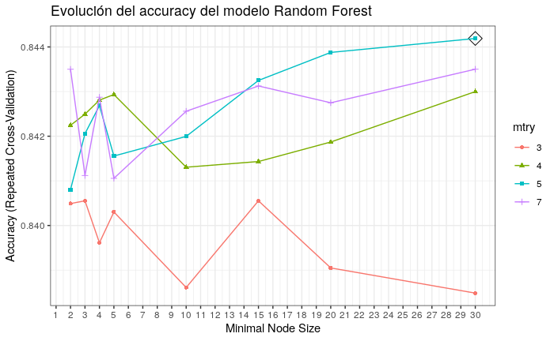

```r
# REPRESENTACIÓN GRÁFICA
# ==============================================================================
ggplot(modelo_rf, highlight = TRUE) +
  scale_x_continuous(breaks = 1:30) +
  labs(title = "Evolución del accuracy del modelo Random Forest") +
  guides(color = guide_legend(title = "mtry"),
         shape = guide_legend(title = "mtry")) +
  theme_bw()
```

## 7.1 Modelar

El mejor modelo determinado con los hiperparmétros queda guardado y se ejecuta nuevamente obteniendo un Accuracy del 84.3% en entrenamiento.

```r
modelo_rf$finalModel
```

```
Ranger result

Call:
 ranger::ranger(dependent.variable.name = ".outcome", data = x,      mtry = min(param$mtry, ncol(x)), min.node.size = param$min.node.size,      splitrule = as.character(param$splitrule), write.forest = TRUE,      probability = classProbs, ...)

Type:                             Classification
Number of trees:                  500
Sample size:                      3191
Number of independent variables:  24
Mtry:                             5
Target node size:                 30
Variable importance mode:         none
Splitrule:                        gini
OOB prediction error:             15.70 %
```

```r
metodo = "RandomForest-Train"

modelo_rf$finalModel$confusion.matrix %>%
  kable(booktabs =T,
               caption = glue::glue("Matriz de Confusion del metodo: {metodo} "),
               label = glue::glue("MatrizConf_{metodo}"),
          align = "c") %>%
    kable_styling(latex_options = c("striped", "hold_position")) %>%
    row_spec(0, bold = T, color = "white", background = "black", align = "c") %>%
    kableExtra::add_header_above(c("Prediccion","Referencia"," "))
```

Matriz de Confusion del metodo: RandomForest-Train

| Prediccion | Referencia 0 | 1 |
| --- | --- | --- |
| 0 | 1589 | 202 |
| 1 | 299 | 1101 |

```r
print("Accuracy:")
```

```
[1] "Accuracy:"
```

```r
1- modelo_rf$finalModel$prediction.error
```

```
[1] 0.8429959
```

```r
(1589+1101)/(1589 + 202 + 299 + 1101)
```

```
[1] 0.8429959
```

## 7.2 Describir el modelo

```r
# unique(predicciones$object)

metodo = "rf"

cf = confusionMatrix(data = predicciones %>% filter(object == "rf") %>%
                  filter(dataType == "Test") %>% pull(pred) ,
                reference = datos_test_prep %>% pull(deserto),
                positive = "1")

tabla_confusionMatrix(cf, metodo)
```

Matriz de Confusion del metodo: rf

| Prediccion | Referencia 0 | 1 |
| --- | --- | --- |
| 0 | 681 | 135 |
| 1 | 86 | 465 |

```r
tabla_metricas(cf, metodo)
```

Métricas del metodo: rf

| metricas | valor |
| --- | --- |
| Accuracy | 0.8383321 |
| Kappa | 0.6688211 |
| AccuracyLower | 0.8177277 |
| AccuracyUpper | 0.8574701 |
| AccuracyNull | 0.5610827 |
| AccuracyPValue | 0.0000000 |
| McnemarPValue | 0.0012430 |
| Sensitivity | 0.7750000 |
| Specificity | 0.8878748 |
| Pos Pred Value | 0.8439201 |
| Neg Pred Value | 0.8345588 |
| Precision | 0.8439201 |
| Recall | 0.7750000 |
| F1 | 0.8079930 |
| Prevalence | 0.4389173 |
| Detection Rate | 0.3401609 |
| Detection Prevalence | 0.4030724 |
| Balanced Accuracy | 0.8314374 |

```r
NA
```

# 8 Gradient Boosting

Boosting es una de las estrategias que hay de ensemble que se pueden aplicar a muchos métodos, entre ellos los árboles. Boosting ajusta de forma secuencia múltiples modelos en cadena. Cada nuevo modelo emplea información del modelo anterior para aprender de sus errores, mejorando iteración a iteración. Utiliza todos los features.

# 9 Determinar parametros del modelo

Estos métodos se caracterizan por tener muchos hiperparámetros y parámetros. En este caso se utiliza el paquete gbm y dentro de el se pueden emplear los siguientes:

- n.trees: número de iteraciones del algoritmo de boosting (cantidad de modelos que forman el ensemble). Cuanto mas grande, mas riesgo de sobreajuste. Se prueban los siguientes valores: 100, 500, 1000, 2000.
- interaction.depth: complejidad de los árboles (cantidad total de divisiones que tiene el árbol). Se preuban los sigientes valores: 1, 5, 9.

shrinkage: (learning rate) controla la influencia que tiene cada modelo sobre el conjunto del ensemble (aprendizaje). Los valores que se probaron son: 0.001, 0.01, 0.1.

n.minobsinnode: número mínimo de observaciones que debe tener un nodo para poder ser dividido. Se probaron los siguientes valores: 2, 10, 20.

distribution: determina la función de coste (loss function). Se utiliza Adaboost.

bag.fraction (subsampling fraction): Si es de 1, se emplea Gradient Boosting, si es menor que 1, se emplea Stochastic Gradient Boosting. Por defecto su valor es de 0.5. Se utiliza valor or defecto.

Se genera una grilla que contempla todas las combinaciones posibles de los valores mencionados anteriormente. Por cada combinación se generan una cantidad igual a particiones*repeticiones.

Todos los resultados dan muy similar. La combinación de hiperparámetros por muy poco y en promedio sobrepasa al resto, es: n.trees = 500, interaction.depth = 9, shrinkage = 0.01 y n.minobsinnode = 10

```r
modelo_boost
```

```
Stochastic Gradient Boosting

3191 samples
  24 predictor
   2 classes: '0', '1'

No pre-processing
Resampling: Cross-Validated (10 fold, repeated 5 times)
Summary of sample sizes: 2872, 2872, 2872, 2872, 2872, 2872, ...
Resampling results across tuning parameters:

  shrinkage  interaction.depth  n.minobsinnode  n.trees  Accuracy   Kappa
  0.001      1                   2               100     0.5612657  0.0000000
  0.001      1                   2               500     0.8047620  0.5878274
  0.001      1                   2              1000     0.8047620  0.5878274
  0.001      1                   2              2000     0.8047620  0.5878274
  0.001      1                  10               100     0.5612657  0.0000000
  0.001      1                  10               500     0.8047620  0.5878274
  0.001      1                  10              1000     0.8047620  0.5878274
  0.001      1                  10              2000     0.8047620  0.5878274
  0.001      1                  20               100     0.5612657  0.0000000
  0.001      1                  20               500     0.8047620  0.5878274
  0.001      1                  20              1000     0.8047620  0.5878274
  0.001      1                  20              2000     0.8047620  0.5878274
  0.001      5                   2               100     0.5612657  0.0000000
  0.001      5                   2               500     0.8278913  0.6395202
  0.001      5                   2              1000     0.8337232  0.6549784
  0.001      5                   2              2000     0.8387384  0.6678832
  0.001      5                  10               100     0.5612657  0.0000000
  0.001      5                  10               500     0.8288315  0.6414994
  0.001      5                  10              1000     0.8340991  0.6558040
  0.001      5                  10              2000     0.8389261  0.6683513
  0.001      5                  20               100     0.5612657  0.0000000
  0.001      5                  20               500     0.8243819  0.6320036
  0.001      5                  20              1000     0.8302132  0.6479565
  0.001      5                  20              2000     0.8391763  0.6688160
  0.001      9                   2               100     0.5612657  0.0000000
  0.001      9                   2               500     0.8347876  0.6559761
  0.001      9                   2              1000     0.8353525  0.6598282
  0.001      9                   2              2000     0.8407433  0.6725845
```

[output cut: 69 more lines]

```
  0.100      9                   2               500     0.8325948  0.6577565
  0.100      9                   2              1000     0.8311509  0.6547442
  0.100      9                   2              2000     0.8299600  0.6523510
  0.100      9                  10               100     0.8393000  0.6712852
  0.100      9                  10               500     0.8311507  0.6548300
  0.100      9                  10              1000     0.8304626  0.6535543
  0.100      9                  10              2000     0.8303997  0.6535886
  0.100      9                  20               100     0.8389888  0.6707469
  0.100      9                  20               500     0.8301499  0.6530756
  0.100      9                  20              1000     0.8270167  0.6467869
  0.100      9                  20              2000     0.8265772  0.6459417

Accuracy was used to select the optimal model using the largest value.
The final values used for the model were n.trees = 500, interaction.depth = 9, shrinkage = 0.01
 and n.minobsinnode = 10.
```

[figure not shown]

```r
# REPRESENTACIÓN GRÁFICA
# ==============================================================================
ggplot(modelo_boost, highlight = TRUE) +
  labs(title = "Evolución del accuracy del modelo Gradient Boosting") +
    guides(color = guide_legend(title = "shrinkage"),
           shape = guide_legend(title = "shrinkage")) +
  theme_bw() +
  coord_cartesian(ylim = c(0.8,0.87)) +
  theme(legend.position = "bottom")
```

## 9.1 Modelar

```r
# unique(predicciones$object)

modelo_boost
```

```
Stochastic Gradient Boosting

3191 samples
  24 predictor
   2 classes: '0', '1'

No pre-processing
Resampling: Cross-Validated (10 fold, repeated 5 times)
Summary of sample sizes: 2872, 2872, 2872, 2872, 2872, 2872, ...
Resampling results across tuning parameters:

  shrinkage  interaction.depth  n.minobsinnode  n.trees  Accuracy   Kappa
  0.001      1                   2               100     0.5612657  0.0000000
  0.001      1                   2               500     0.8047620  0.5878274
  0.001      1                   2              1000     0.8047620  0.5878274
  0.001      1                   2              2000     0.8047620  0.5878274
  0.001      1                  10               100     0.5612657  0.0000000
  0.001      1                  10               500     0.8047620  0.5878274
  0.001      1                  10              1000     0.8047620  0.5878274
  0.001      1                  10              2000     0.8047620  0.5878274
  0.001      1                  20               100     0.5612657  0.0000000
  0.001      1                  20               500     0.8047620  0.5878274
  0.001      1                  20              1000     0.8047620  0.5878274
  0.001      1                  20              2000     0.8047620  0.5878274
  0.001      5                   2               100     0.5612657  0.0000000
  0.001      5                   2               500     0.8278913  0.6395202
  0.001      5                   2              1000     0.8337232  0.6549784
  0.001      5                   2              2000     0.8387384  0.6678832
  0.001      5                  10               100     0.5612657  0.0000000
  0.001      5                  10               500     0.8288315  0.6414994
  0.001      5                  10              1000     0.8340991  0.6558040
  0.001      5                  10              2000     0.8389261  0.6683513
  0.001      5                  20               100     0.5612657  0.0000000
  0.001      5                  20               500     0.8243819  0.6320036
  0.001      5                  20              1000     0.8302132  0.6479565
  0.001      5                  20              2000     0.8391763  0.6688160
  0.001      9                   2               100     0.5612657  0.0000000
  0.001      9                   2               500     0.8347876  0.6559761
  0.001      9                   2              1000     0.8353525  0.6598282
  0.001      9                   2              2000     0.8407433  0.6725845
```

[output cut: 69 more lines]

```
  0.100      9                   2               500     0.8325948  0.6577565
  0.100      9                   2              1000     0.8311509  0.6547442
  0.100      9                   2              2000     0.8299600  0.6523510
  0.100      9                  10               100     0.8393000  0.6712852
  0.100      9                  10               500     0.8311507  0.6548300
  0.100      9                  10              1000     0.8304626  0.6535543
  0.100      9                  10              2000     0.8303997  0.6535886
  0.100      9                  20               100     0.8389888  0.6707469
  0.100      9                  20               500     0.8301499  0.6530756
  0.100      9                  20              1000     0.8270167  0.6467869
  0.100      9                  20              2000     0.8265772  0.6459417

Accuracy was used to select the optimal model using the largest value.
The final values used for the model were n.trees = 500, interaction.depth = 9, shrinkage = 0.01
 and n.minobsinnode = 10.
```

```r
metodo = "boosting"

cf = confusionMatrix(data = predicciones %>% filter(object == "boosting") %>%
                  filter(dataType == "Training") %>% pull(pred) ,
                reference = datos_train_prep %>% pull(deserto),
                positive = "1")

metodo = "GradientBoosting-Train"
tabla_confusionMatrix(cf, metodo)
```

Matriz de Confusion del metodo: GradientBoosting-Train

| Prediccion | Referencia 0 | 1 |
| --- | --- | --- |
| 0 | 1631 | 242 |
| 1 | 160 | 1158 |

```r
tabla_metricas(cf, metodo)
```

Métricas del metodo: GradientBoosting-Train

| metricas | valor |
| --- | --- |
| Accuracy | 0.8740207 |
| Kappa | 0.7425548 |
| AccuracyLower | 0.8620072 |
| AccuracyUpper | 0.8853438 |
| AccuracyNull | 0.5612661 |
| AccuracyPValue | 0.0000000 |
| McnemarPValue | 0.0000535 |
| Sensitivity | 0.8271429 |
| Specificity | 0.9106644 |
| Pos Pred Value | 0.8786039 |
| Neg Pred Value | 0.8707955 |
| Precision | 0.8786039 |
| Recall | 0.8271429 |
| F1 | 0.8520971 |
| Prevalence | 0.4387339 |
| Detection Rate | 0.3628956 |
| Detection Prevalence | 0.4130367 |
| Balanced Accuracy | 0.8689036 |

```r
NA
NA
NA
```

## 9.2 Describir el modelo

```r
metodo = "boosting"

cf = confusionMatrix(data = predicciones %>% filter(object == "boosting") %>%
                  filter(dataType == "Test") %>% pull(pred) ,
                reference = datos_test_prep %>% pull(deserto),
                positive = "1")

tabla_confusionMatrix(cf, metodo)
```

Matriz de Confusion del metodo: boosting

| Prediccion | Referencia 0 | 1 |
| --- | --- | --- |
| 0 | 678 | 135 |
| 1 | 89 | 465 |

```r
tabla_metricas(cf, metodo)
```

Métricas del metodo: boosting

| metricas | valor |
| --- | --- |
| Accuracy | 0.8361375 |
| Kappa | 0.6645097 |
| AccuracyLower | 0.8154319 |
| AccuracyUpper | 0.8553864 |
| AccuracyNull | 0.5610827 |
| AccuracyPValue | 0.0000000 |
| McnemarPValue | 0.0026411 |
| Sensitivity | 0.7750000 |
| Specificity | 0.8839635 |
| Pos Pred Value | 0.8393502 |
| Neg Pred Value | 0.8339483 |
| Precision | 0.8393502 |
| Recall | 0.7750000 |
| F1 | 0.8058925 |
| Prevalence | 0.4389173 |
| Detection Rate | 0.3401609 |
| Detection Prevalence | 0.4052670 |
| Balanced Accuracy | 0.8294817 |

```r
NA
NA
```

# 10 SVM

Este algoritmo se basa en la separacion de las clases con hiperplanos y utilizando kernels para aumentar las dimensiones.

## 10.1 Determinar parametros del modelo

Se utiliza el paquete kernlab que tiene 2 hiperparámetros:

- sigma: coeficiente del kernel radial. Se preuban los valores: 0.001, 0.01, 0.1, 0.5, 1.
- C: penalización por violaciones del margen del hiperplano. se preuabn los valores: 1 , 20, 50, 100, 200, 500, 700.

Los mejores resultados a traves de las iteraciones de los modelos generados fue con los valores: sigma = 0.001 y C = 100. Los mismos se contrastan con los valores de Accuracy obtenidos en cada modelo y cuya evolución puede verse en el grafico x.

```r
modelo_svmrad
```

```
Support Vector Machines with Radial Basis Function Kernel

3191 samples
  24 predictor
   2 classes: '0', '1'

No pre-processing
Resampling: Cross-Validated (10 fold, repeated 5 times)
Summary of sample sizes: 2872, 2872, 2872, 2872, 2872, 2872, ...
Resampling results across tuning parameters:

  sigma  C    Accuracy   Kappa
  0.001    1  0.8153017  0.6159483
  0.001   20  0.8330995  0.6535084
  0.001   50  0.8349150  0.6578038
  0.001  100  0.8379236  0.6647011
  0.001  200  0.8376738  0.6646719
  0.001  500  0.8369214  0.6638295
  0.001  700  0.8361060  0.6623453
  0.010    1  0.8280848  0.6440551
  0.010   20  0.8312802  0.6525438
  0.010   50  0.8330335  0.6568089
  0.010  100  0.8296479  0.6507086
  0.010  200  0.8297102  0.6512823
  0.010  500  0.8191179  0.6302330
  0.010  700  0.8152939  0.6227724
  0.100    1  0.8194978  0.6283111
  0.100   20  0.7936720  0.5791574
  0.100   50  0.7867766  0.5657027
  0.100  100  0.7825137  0.5573009
  0.100  200  0.7791299  0.5504630
  0.100  500  0.7768135  0.5457997
  0.100  700  0.7747461  0.5416849
  0.500    1  0.7430247  0.4530058
  0.500   20  0.7467847  0.4666903
  0.500   50  0.7472236  0.4676572
  0.500  100  0.7475366  0.4683001
  0.500  200  0.7467220  0.4665594
  0.500  500  0.7467220  0.4665594
  0.500  700  0.7467220  0.4665594
  1.000    1  0.6673754  0.2693606
  1.000   20  0.6806009  0.3050287
  1.000   50  0.6804126  0.3046084
  1.000  100  0.6804126  0.3046084
  1.000  200  0.6804126  0.3046084
  1.000  500  0.6804126  0.3046084
  1.000  700  0.6804126  0.3046084

Accuracy was used to select the optimal model using the largest value.
The final values used for the model were sigma = 0.001 and C = 100.
```

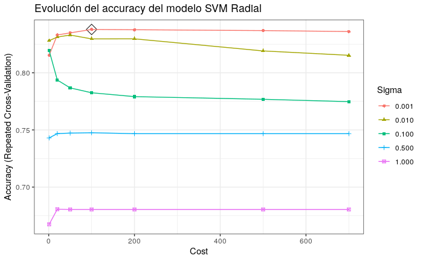

```r
# REPRESENTACIÓN GRÁFICA
# ==============================================================================
ggplot(modelo_svmrad, highlight = TRUE) +
  labs(title = "Evolución del accuracy del modelo SVM Radial") +
  theme_bw()
```

## 10.2 Modelar

En entrenamiento se consigue un Accuracy de 83.79% (con validation) y 85.11% sin validation.

```r
modelo_svmrad$finalModel
```

```
Support Vector Machine object of class "ksvm"

SV type: C-svc  (classification)
 parameter : cost C = 100

Gaussian Radial Basis kernel function.
 Hyperparameter : sigma =  0.001

Number of Support Vectors : 1227

Objective Function Value : -113728.8
Training error : 0.148856
```

```r
1 - 0.148856
```

```
[1] 0.851144
```

```r
# unique(predicciones$object)

metodo = "SVMradial"

cf = confusionMatrix(data = predicciones %>% filter(object == "SVMradial") %>%
                  filter(dataType == "Training") %>% pull(pred) ,
                reference = datos_train_prep %>% pull(deserto),
                positive = "1")

metodo = "SVMradial-Train"
tabla_confusionMatrix(cf, metodo)
```

Matriz de Confusion del metodo: SVMradial-Train

| Prediccion | Referencia 0 | 1 |
| --- | --- | --- |
| 0 | 1668 | 352 |
| 1 | 123 | 1048 |

```r
tabla_metricas(cf, metodo)
```

Métricas del metodo: SVMradial-Train

| metricas | valor |
| --- | --- |
| Accuracy | 0.8511438 |
| Kappa | 0.6922549 |
| AccuracyLower | 0.8383158 |
| AccuracyUpper | 0.8633246 |
| AccuracyNull | 0.5612661 |
| AccuracyPValue | 0.0000000 |
| McnemarPValue | 0.0000000 |
| Sensitivity | 0.7485714 |
| Specificity | 0.9313233 |
| Pos Pred Value | 0.8949616 |
| Neg Pred Value | 0.8257426 |
| Precision | 0.8949616 |
| Recall | 0.7485714 |
| F1 | 0.8152470 |
| Prevalence | 0.4387339 |
| Detection Rate | 0.3284237 |
| Detection Prevalence | 0.3669696 |
| Balanced Accuracy | 0.8399474 |

```r
NA
NA
```

##Descripción del modelo

Evaluando en el conjinto de Test se obtiene 84.2% Accuracy.

```r
metodo = "SVMradial"

cf = confusionMatrix(data = predicciones %>% filter(object == "SVMradial") %>%
                  filter(dataType == "Test") %>% pull(pred) ,
                reference = datos_test_prep %>% pull(deserto),
                positive = "1")

tabla_confusionMatrix(cf, metodo)
```

Matriz de Confusion del metodo: SVMradial

| Prediccion | Referencia 0 | 1 |
| --- | --- | --- |
| 0 | 709 | 158 |
| 1 | 58 | 442 |

```r
tabla_metricas(cf, metodo)
```

Métricas del metodo: SVMradial

| metricas | valor |
| --- | --- |
| Accuracy | 0.8419898 |
| Kappa | 0.6732633 |
| AccuracyLower | 0.8215568 |
| AccuracyUpper | 0.8609401 |
| AccuracyNull | 0.5610827 |
| AccuracyPValue | 0.0000000 |
| McnemarPValue | 0.0000000 |
| Sensitivity | 0.7366667 |
| Specificity | 0.9243807 |
| Pos Pred Value | 0.8840000 |
| Neg Pred Value | 0.8177624 |
| Precision | 0.8840000 |
| Recall | 0.7366667 |
| F1 | 0.8036364 |
| Prevalence | 0.4389173 |
| Detection Rate | 0.3233358 |
| Detection Prevalence | 0.3657644 |
| Balanced Accuracy | 0.8305237 |

```r
NA
NA
```

# 11 Modelos con Dataset de variables Reducido

Se pueden utilizar todas las variables, pero scmo se mencionó anteriormente durante el entrenamiento se comprobaron mejores resultados con datasets con menos variables. En este caso son 10 variables:

[1] “ciclo_lectivo_de_cursada” “tipo_de_aprobacion_libre” “Turno_Noche”  
[4] “tipo_de_aprobacion_no_firmo” “Aprobado” “Turno_Tarde”  
[7] “Nota_max_prom” “tipo_de_aprobacion_firmo” “Turno_Manana”  
[10] “cant_resursada_regular”

Por lo que se seleccionaron 3 métodos, para realizar todo el proceso anterior nuevamente pero solamene teniendo en cuenta estos predictores. de esta forma y evaluandolo con el conjunto de Test se comprobará que es mejor.

## 11.1 Determinar parámetros

Las grillas de preubas de parámetros es igual para cada modelo que los mencionados anteriormente las secciones de cada modelo por separado.

```r
grid_modelos_4var$model_fits
```

```
$RandomForest
Random Forest

3191 samples
  10 predictor
   2 classes: '0', '1'

No pre-processing
Resampling: Cross-Validated (5 fold, repeated 8 times)
Summary of sample sizes: 2553, 2553, 2552, 2553, 2553, 2553, ...
Resampling results across tuning parameters:

  mtry  min.node.size  Accuracy   Kappa
  3      2             0.8402566  0.6729637
  3      3             0.8399044  0.6721908
  3      4             0.8398650  0.6721515
  3      5             0.8401388  0.6727699
  3     10             0.8411571  0.6748184
  3     15             0.8418232  0.6763003
  3     20             0.8428417  0.6784827
  3     30             0.8434285  0.6796168
  4      2             0.8389243  0.6702716
  4      3             0.8380234  0.6683855
  4      4             0.8389249  0.6702389
  4      5             0.8390034  0.6703180
  4     10             0.8414709  0.6754611
  4     15             0.8410398  0.6745944
  4     20             0.8419796  0.6766335
  4     30             0.8432330  0.6791114
  5      2             0.8372407  0.6668464
  5      3             0.8370831  0.6665059
  5      4             0.8391985  0.6708436
  5      5             0.8367308  0.6658576
  5     10             0.8395504  0.6715448
  5     15             0.8409218  0.6743952
  5     20             0.8414701  0.6756383
  5     30             0.8426070  0.6778691
  7      2             0.8357903  0.6640102
  7      3             0.8361824  0.6647902
  7      4             0.8354773  0.6634469
```

[output cut: 9 more lines]

```

$Reg_logistica
Generalized Linear Model

3191 samples
  10 predictor
   2 classes: '0', '1'

No pre-processing
Resampling: Cross-Validated (5 fold, repeated 8 times)
Summary of sample sizes: 2553, 2553, 2552, 2553, 2553, 2553, ...
Resampling results:

  Accuracy   Kappa
  0.8313254  0.6508567
```

## 11.2 Modelar

Los valores de Accuracy obtenidos en entrenamiento:

Random Forest 0.8434285 (con validation) 0.8442495 (usando todo train) Reg_logistica 0.8313254 0.8345

```r
table(is.na(predicciones2$pred))
```

```
FALSE
 9116
```

```r
grid_modelos_4var$model_fits$RandomForest$finalModel$confusion.matrix
```

```
    predicted
true    0    1
   0 1589  202
   1  295 1105
```

```r
1- grid_modelos_4var$model_fits$RandomForest$finalModel$prediction.error
```

```
[1] 0.8442495
```

```r
grid_modelos_4var$model_fits$Reg_logistica$finalModel
```

```
Call:  NULL

Coefficients:
                (Intercept)     ciclo_lectivo_de_cursada     tipo_de_aprobacion_libre
                    0.35119                     -3.13263                      0.74772
                Turno_Noche  tipo_de_aprobacion_no_firmo                     Aprobado
                   -0.32733                      0.61234                     -0.57555
                Turno_Tarde                Nota_max_prom     tipo_de_aprobacion_firmo
                   -0.24499                      0.18274                     -0.06436
               Turno_Manana       cant_resursada_regular
                   -0.43394                     -0.04067

Degrees of Freedom: 3190 Total (i.e. Null);  3180 Residual
Null Deviance:      4376
Residual Deviance: 2330     AIC: 2352
```

```r
unique(predicciones2$object)
```

```
[1] RandomForest  Reg_logistica
Levels: RandomForest Reg_logistica
```

```r
metodo = "Reg_logistica"

cf = confusionMatrix(data = predicciones2 %>% filter(object == "Reg_logistica") %>%
                  filter(dataType == "Training") %>% pull(pred) ,
                reference = datos_train_prep %>% pull(deserto),
                positive = "1")

metodo = "Reg_logistica-Training"
tabla_confusionMatrix(cf, metodo)
```

Matriz de Confusion del metodo: Reg_logistica-Training

| Prediccion | Referencia 0 | 1 |
| --- | --- | --- |
| 0 | 1651 | 388 |
| 1 | 140 | 1012 |

```r
tabla_metricas(cf, metodo)
```

Métricas del metodo: Reg_logistica-Training

| metricas | valor |
| --- | --- |
| Accuracy | 0.8345346 |
| Kappa | 0.6574003 |
| AccuracyLower | 0.8211795 |
| AccuracyUpper | 0.8472735 |
| AccuracyNull | 0.5612661 |
| AccuracyPValue | 0.0000000 |
| McnemarPValue | 0.0000000 |
| Sensitivity | 0.7228571 |
| Specificity | 0.9218314 |
| Pos Pred Value | 0.8784722 |
| Neg Pred Value | 0.8097106 |
| Precision | 0.8784722 |
| Recall | 0.7228571 |
| F1 | 0.7931034 |
| Prevalence | 0.4387339 |
| Detection Rate | 0.3171420 |
| Detection Prevalence | 0.3610154 |
| Balanced Accuracy | 0.8223443 |

```r
NA
```

## 11.3 describir el modelo

con Test

```r
# unique(predicciones2$dataType)

metodo = "RandomForest"

length(predicciones2 %>% filter(object == "RandomForest") %>%
                  filter(dataType == "Test") %>% pull(pred))
```

```
[1] 1367
```

```r
cf = confusionMatrix(data = predicciones2 %>% filter(object == "RandomForest") %>%
                  filter(dataType == "Test") %>% pull(pred) ,
                reference = datos_test_prep %>% pull(deserto),
                positive = "1")

tabla_confusionMatrix(cf, metodo)
```

Matriz de Confusion del metodo: RandomForest

| Prediccion | Referencia 0 | 1 |
| --- | --- | --- |
| 0 | 683 | 135 |
| 1 | 84 | 465 |

```r
tabla_metricas(cf, metodo)
```

Métricas del metodo: RandomForest

| metricas | valor |
| --- | --- |
| Accuracy | 0.8397952 |
| Kappa | 0.6716980 |
| AccuracyLower | 0.8192589 |
| AccuracyUpper | 0.8588586 |
| AccuracyNull | 0.5610827 |
| AccuracyPValue | 0.0000000 |
| McnemarPValue | 0.0007283 |
| Sensitivity | 0.7750000 |
| Specificity | 0.8904824 |
| Pos Pred Value | 0.8469945 |
| Neg Pred Value | 0.8349633 |
| Precision | 0.8469945 |
| Recall | 0.7750000 |
| F1 | 0.8093995 |
| Prevalence | 0.4389173 |
| Detection Rate | 0.3401609 |
| Detection Prevalence | 0.4016094 |
| Balanced Accuracy | 0.8327412 |

```r
NA
```

```r
# unique(predicciones2$dataType)

metodo = "Reg_logistica"

length(predicciones2 %>% filter(object == "Reg_logistica") %>%
                  filter(dataType == "Test") %>% pull(pred))
```

```
[1] 1367
```

```r
cf = confusionMatrix(data = predicciones2 %>% filter(object == "RandomForest") %>%
                  filter(dataType == "Test") %>% pull(pred) ,
                reference = datos_test_prep %>% pull(deserto),
                positive = "1")

tabla_confusionMatrix(cf, metodo)
```

| Prediccion | Referencia 0 | 1 |
| --- | --- | --- |
| 0 | 684 | 135 |
| 1 | 83 | 465 |

```r
tabla_metricas(cf, metodo)
```

| metricas | valor |
| --- | --- |
| Accuracy | 0.8405267 |
| Kappa | 0.6731372 |
| AccuracyLower | 0.8200248 |
| AccuracyUpper | 0.8595526 |
| AccuracyNull | 0.5610827 |
| AccuracyPValue | 0.0000000 |
| McnemarPValue | 0.0005520 |
| Sensitivity | 0.7750000 |
| Specificity | 0.8917862 |
| Pos Pred Value | 0.8485401 |
| Neg Pred Value | 0.8351648 |
| Precision | 0.8485401 |
| Recall | 0.7750000 |
| F1 | 0.8101045 |
| Prevalence | 0.4389173 |
| Detection Rate | 0.3401609 |
| Detection Prevalence | 0.4008778 |
| Balanced Accuracy | 0.8333931 |

```r
NA
```

# 12 Modelos con Dataset sin variable ciclo_lectivo_de_cursada

En este caso, se generan algunos modelos pero usando el dataset sin la variable que mayor relevancia tomaba para los modelos anteriores (sin “ciclo_lectivo_de_cursada”)

Los modelos seleccionados para estas pruebas son: Regresión logística, RandomForest, knn y GradientBoosting.

```r
grid_modelos_sinCicloLectivo <- grid_modelos_sinCicloLectivo %>%
                remove_model(model_name = "SVM")
```

```
Model fit for SVM has been deleted.
```

```r
grid_modelos_sinCicloLectivo_knn_gbm <- grid_modelos_sinCicloLectivo_knn_gbm %>%
                remove_model(model_name = "KNN_3")
```

```
Model fit for KNN_3 has been deleted.
```

```r
names(grid_modelos_sinCicloLectivo$model_fits)
```

```
[1] "RandomForest"  "Reg_logistica"
```

```r
names(grid_modelos_sinCicloLectivo_knn_gbm$model_fits)
```

```
[1] "GradienBoosting_3"
```

```r
grid_modelos_sinCicloLectivo_knn_gbm$model_fits
```

```
$GradienBoosting_3
Stochastic Gradient Boosting

3191 samples
   9 predictor
   2 classes: '0', '1'

No pre-processing
Resampling: Cross-Validated (5 fold, repeated 8 times)
Summary of sample sizes: 2553, 2553, 2552, 2553, 2553, 2553, ...
Resampling results across tuning parameters:

  shrinkage  interaction.depth  n.minobsinnode  n.trees  Accuracy   Kappa
  0.001      1                   2               500     0.7097712  0.4135733
  0.001      1                   2              1000     0.7181152  0.4322519
  0.001      1                   2              2000     0.7348411  0.4614070
  0.001      1                   5               500     0.7094969  0.4127321
  0.001      1                   5              1000     0.7183108  0.4326995
  0.001      1                   5              2000     0.7348411  0.4614168
  0.001      1                  15               500     0.7103196  0.4149736
  0.001      1                  15              1000     0.7181937  0.4323522
  0.001      1                  15              2000     0.7342147  0.4601123
  0.001      2                   2               500     0.7268511  0.4302101
  0.001      2                   2              1000     0.7403639  0.4677604
  0.001      2                   2              2000     0.7507051  0.4912349
  0.001      2                   5               500     0.7266942  0.4299188
  0.001      2                   5              1000     0.7407165  0.4684953
  0.001      2                   5              2000     0.7508621  0.4915558
  0.001      2                  15               500     0.7258714  0.4281312
  0.001      2                  15              1000     0.7410688  0.4693392
  0.001      2                  15              2000     0.7510579  0.4920116
  0.010      1                   2               500     0.7536438  0.4987455
  0.010      1                   2              1000     0.7632409  0.5186205
  0.010      1                   2              2000     0.7691957  0.5305265
  0.010      1                   5               500     0.7540755  0.4995368
  0.010      1                   5              1000     0.7623002  0.5166580
  0.010      1                   5              2000     0.7693916  0.5309110
  0.010      1                  15               500     0.7536834  0.4988552
  0.010      1                  15              1000     0.7626528  0.5174907
  0.010      1                  15              2000     0.7699792  0.5320814
```

[output cut: 15 more lines]

```
  0.100      1                  15               500     0.7716241  0.5350175
  0.100      1                  15              1000     0.7677855  0.5270363
  0.100      1                  15              2000     0.7620665  0.5150443
  0.100      2                   2               500     0.7703708  0.5329246
  0.100      2                   2              1000     0.7659064  0.5238798
  0.100      2                   2              2000     0.7614013  0.5147818
  0.100      2                   5               500     0.7675517  0.5270057
  0.100      2                   5              1000     0.7628513  0.5178061
  0.100      2                   5              2000     0.7576412  0.5070964
  0.100      2                  15               500     0.7681004  0.5282994
  0.100      2                  15              1000     0.7647714  0.5214325
  0.100      2                  15              2000     0.7587369  0.5092640

Accuracy was used to select the optimal model using the largest value.
The final values used for the model were n.trees = 2000, interaction.depth = 2, shrinkage = 0.01 and n.minobsinnode = 15.
```

```r
grid_modelos_sinCicloLectivo$model_fits
```

```
$RandomForest
Random Forest

3191 samples
   9 predictor
   2 classes: '0', '1'

No pre-processing
Resampling: Cross-Validated (5 fold, repeated 8 times)
Summary of sample sizes: 2553, 2553, 2552, 2553, 2553, 2553, ...
Resampling results across tuning parameters:

  mtry  min.node.size  Accuracy   Kappa
  3      2             0.7671206  0.5282249
  3      3             0.7665719  0.5271329
  3      4             0.7672766  0.5285668
  3      5             0.7666903  0.5274872
  3     10             0.7700196  0.5341778
  3     15             0.7695101  0.5334912
  3     20             0.7697845  0.5340891
  3     30             0.7720178  0.5387246
  4      2             0.7646133  0.5231270
  4      3             0.7664932  0.5268484
  4      4             0.7659055  0.5259800
  4      5             0.7656712  0.5253449
  4     10             0.7676689  0.5295171
  4     15             0.7699800  0.5343340
  4     20             0.7693140  0.5329868
  4     30             0.7708810  0.5363738
  5      2             0.7640269  0.5217434
  5      3             0.7630079  0.5197385
  5      4             0.7646127  0.5229645
  5      5             0.7644957  0.5229746
  5     10             0.7671606  0.5285420
  5     15             0.7682956  0.5307551
  5     20             0.7683344  0.5309660
  5     30             0.7699800  0.5343229
  7      2             0.7609303  0.5154202
  7      3             0.7621059  0.5177764
  7      4             0.7632023  0.5202340
```

[output cut: 9 more lines]

```

$Reg_logistica
Generalized Linear Model

3191 samples
   9 predictor
   2 classes: '0', '1'

No pre-processing
Resampling: Cross-Validated (5 fold, repeated 8 times)
Summary of sample sizes: 2553, 2553, 2552, 2553, 2553, 2553, ...
Resampling results:

  Accuracy   Kappa
  0.7532915  0.5033037
```

## 12.1 Determinar parámetros

Las grillas de preubas de parámetros es igual para cada modelo que los mencionados anteriormente las secciones de cada modelo por separado.

Se detallan los nuevos parámetros óptimos encontrados: RandomForest mtry = 3, splitrule = gini and min.node.size = 30 Reg_logistica (sin parametros) gbm n.trees = 2000, interaction.depth = 2, shrinkage = 0.01 y n.minobsinnode = 15

```r
grid_modelos_sinCicloLectivo_knn_gbm$model_fits
```

```
$GradienBoosting_3
Stochastic Gradient Boosting

3191 samples
   9 predictor
   2 classes: '0', '1'

No pre-processing
Resampling: Cross-Validated (5 fold, repeated 8 times)
Summary of sample sizes: 2553, 2553, 2552, 2553, 2553, 2553, ...
Resampling results across tuning parameters:

  shrinkage  interaction.depth  n.minobsinnode  n.trees  Accuracy   Kappa
  0.001      1                   2               500     0.7097712  0.4135733
  0.001      1                   2              1000     0.7181152  0.4322519
  0.001      1                   2              2000     0.7348411  0.4614070
  0.001      1                   5               500     0.7094969  0.4127321
  0.001      1                   5              1000     0.7183108  0.4326995
  0.001      1                   5              2000     0.7348411  0.4614168
  0.001      1                  15               500     0.7103196  0.4149736
  0.001      1                  15              1000     0.7181937  0.4323522
  0.001      1                  15              2000     0.7342147  0.4601123
  0.001      2                   2               500     0.7268511  0.4302101
  0.001      2                   2              1000     0.7403639  0.4677604
  0.001      2                   2              2000     0.7507051  0.4912349
  0.001      2                   5               500     0.7266942  0.4299188
  0.001      2                   5              1000     0.7407165  0.4684953
  0.001      2                   5              2000     0.7508621  0.4915558
  0.001      2                  15               500     0.7258714  0.4281312
  0.001      2                  15              1000     0.7410688  0.4693392
  0.001      2                  15              2000     0.7510579  0.4920116
  0.010      1                   2               500     0.7536438  0.4987455
  0.010      1                   2              1000     0.7632409  0.5186205
  0.010      1                   2              2000     0.7691957  0.5305265
  0.010      1                   5               500     0.7540755  0.4995368
  0.010      1                   5              1000     0.7623002  0.5166580
  0.010      1                   5              2000     0.7693916  0.5309110
  0.010      1                  15               500     0.7536834  0.4988552
  0.010      1                  15              1000     0.7626528  0.5174907
  0.010      1                  15              2000     0.7699792  0.5320814
```

[output cut: 40 more lines]

```
Summary of sample sizes: 2553, 2553, 2552, 2553, 2553, 2553, ...
Resampling results across tuning parameters:

  k   Accuracy   Kappa
   1  0.6885779  0.3659885
   2  0.6900275  0.3685721
   5  0.7280248  0.4484623
  10  0.7410316  0.4753485
  15  0.7498834  0.4936818
  20  0.7512547  0.4964559
  30  0.7563477  0.5074531
  50  0.7544669  0.5039269

Accuracy was used to select the optimal model using the largest value.
The final value used for the model was k = 30.
```

```r
predicciones4 <- extractPrediction(
                  # models = list( KNN_3 = grid_modelos_sinCicloLectivo_knn_gbm$model_fits$KNN_3,
                                 GBM_3 = grid_modelos_sinCicloLectivo_knn_gbm$model_fits$GradienBoosting_3),
```

[output not shown]

## 12.2 Modelar

Los valores de Accuracy obtenidos en entrenamiento:

```r
grid_modelos_sinCicloLectivo$model_fits$RandomForest$finalModel$confusion.matrix
```

```
    predicted
true    0    1
   0 1407  384
   1  340 1060
```

```r
1- grid_modelos_sinCicloLectivo$model_fits$RandomForest$finalModel$prediction.error
```

```
[1] 0.7731119
```

```r
grid_modelos_sinCicloLectivo$model_fits$Reg_logistica$finalModel
```

```
Call:  NULL

Coefficients:
                (Intercept)     tipo_de_aprobacion_libre                  Turno_Noche
                   -0.54964                      1.02282                     -0.94356
tipo_de_aprobacion_no_firmo                     Aprobado                  Turno_Tarde
                    0.77148                     -0.90726                     -0.67434
              Nota_max_prom     tipo_de_aprobacion_firmo                 Turno_Manana
                    0.02305                      0.66797                     -0.97639
     cant_resursada_regular
                   -0.05740

Degrees of Freedom: 3190 Total (i.e. Null);  3181 Residual
Null Deviance:      4376
Residual Deviance: 3336     AIC: 3356
```

```r
unique(predicciones3$object)
```

```
[1] RandomForest_3  Reg_Logistica_3
Levels: RandomForest_3 Reg_Logistica_3
```

```r
metodo = "Reg_Logistica_3"

cf = confusionMatrix(data = predicciones3 %>% filter(object == "Reg_Logistica_3") %>%
                  filter(dataType == "Training") %>% pull(pred) ,
                reference = datos_train_prep %>% pull(deserto),
                positive = "1")

metodo = "Reg_logistica_3-Training"
tabla_confusionMatrix(cf, metodo)
```

Matriz de Confusion del metodo: Reg_logistica_3-Training

| Prediccion | Referencia 0 | 1 |
| --- | --- | --- |
| 0 | 1343 | 331 |
| 1 | 448 | 1069 |

```r
tabla_metricas(cf, metodo)
```

Métricas del metodo: Reg_logistica_3-Training

| metricas | valor |
| --- | --- |
| Accuracy | 0.7558759 |
| Kappa | 0.5087905 |
| AccuracyLower | 0.7405843 |
| AccuracyUpper | 0.7706971 |
| AccuracyNull | 0.5612661 |
| AccuracyPValue | 0.0000000 |
| McnemarPValue | 0.0000324 |
| Sensitivity | 0.7635714 |
| Specificity | 0.7498604 |
| Pos Pred Value | 0.7046803 |
| Neg Pred Value | 0.8022700 |
| Precision | 0.7046803 |
| Recall | 0.7635714 |
| F1 | 0.7329448 |
| Prevalence | 0.4387339 |
| Detection Rate | 0.3350047 |
| Detection Prevalence | 0.4753996 |
| Balanced Accuracy | 0.7567159 |

```r
NA
```

```r
grid_modelos_sinCicloLectivo_knn_gbm$model_fits$GradienBoosting_3$finalModel
```

```
A gradient boosted model with adaboost loss function.
2000 iterations were performed.
There were 9 predictors of which 9 had non-zero influence.
```

```r
unique(predicciones4$object)
```

```
[1] GBM_3
Levels: GBM_3
```

```r
metodo = "GBM_3"

cf = confusionMatrix(data = predicciones4 %>% filter(object == "GBM_3") %>%
                  filter(dataType == "Training") %>% pull(pred) ,
                reference = datos_train_prep %>% pull(deserto),
                positive = "1")

metodo = "GBM_3-Training"
tabla_confusionMatrix(cf, metodo)
```

Matriz de Confusion del metodo: GBM_3-Training

| Prediccion | Referencia 0 | 1 |
| --- | --- | --- |
| 0 | 1465 | 338 |
| 1 | 326 | 1062 |

```r
tabla_metricas(cf, metodo)
```

Métricas del metodo: GBM_3-Training

| metricas | valor |
| --- | --- |
| Accuracy | 0.7919148 |
| Kappa | 0.5770902 |
| AccuracyLower | 0.7774089 |
| AccuracyUpper | 0.8058835 |
| AccuracyNull | 0.5612661 |
| AccuracyPValue | 0.0000000 |
| McnemarPValue | 0.6694647 |
| Sensitivity | 0.7585714 |
| Specificity | 0.8179788 |
| Pos Pred Value | 0.7651297 |
| Neg Pred Value | 0.8125347 |
| Precision | 0.7651297 |
| Recall | 0.7585714 |
| F1 | 0.7618364 |
| Prevalence | 0.4387339 |
| Detection Rate | 0.3328110 |
| Detection Prevalence | 0.4349734 |
| Balanced Accuracy | 0.7882751 |

## 12.3 describir el modelo

con Test

RandomFores 0.7717630 Reg_Logistica 0.7439649 gbm 0.6949525

```r
unique(predicciones3$object)
```

```
[1] RandomForest_3  Reg_Logistica_3
Levels: RandomForest_3 Reg_Logistica_3
```

```r
# unique(predicciones2$dataType)

metodo = "Reg_Logistica_3"

cf = confusionMatrix(data = predicciones3 %>% filter(object == "Reg_Logistica_3") %>%
                  filter(dataType == "Test") %>% pull(pred) ,
                reference = datos_test_prep %>% pull(deserto),
                positive = "1")

tabla_confusionMatrix(cf, metodo)
```

Matriz de Confusion del metodo: Reg_Logistica_3

| Prediccion | Referencia 0 | 1 |
| --- | --- | --- |
| 0 | 574 | 157 |
| 1 | 193 | 443 |

```r
tabla_metricas(cf, metodo)
```

Métricas del metodo: Reg_Logistica_3

| metricas | valor |
| --- | --- |
| Accuracy | 0.7439649 |
| Kappa | 0.4835451 |
| AccuracyLower | 0.7199541 |
| AccuracyUpper | 0.7669222 |
| AccuracyNull | 0.5610827 |
| AccuracyPValue | 0.0000000 |
| McnemarPValue | 0.0613688 |
| Sensitivity | 0.7383333 |
| Specificity | 0.7483703 |
| Pos Pred Value | 0.6965409 |
| Neg Pred Value | 0.7852257 |
| Precision | 0.6965409 |
| Recall | 0.7383333 |
| F1 | 0.7168285 |
| Prevalence | 0.4389173 |
| Detection Rate | 0.3240673 |
| Detection Prevalence | 0.4652524 |
| Balanced Accuracy | 0.7433518 |

```r
NA
```

```r
metodo = "GBM_3"


cf = confusionMatrix(data = predicciones4 %>% filter(object == "GBM_3") %>%
                  filter(dataType == "Test") %>% pull(pred) ,
                reference = datos_test_prep %>% pull(deserto),
                positive = "1")

tabla_confusionMatrix(cf, metodo)
```

Matriz de Confusion del metodo: GBM_3

| Prediccion | Referencia 0 | 1 |
| --- | --- | --- |
| 0 | 617 | 267 |
| 1 | 150 | 333 |

```r
tabla_metricas(cf, metodo)
```

Métricas del metodo: GBM_3

| metricas | valor |
| --- | --- |
| Accuracy | 0.6949525 |
| Kappa | 0.3672287 |
| AccuracyLower | 0.6697789 |
| AccuracyUpper | 0.7192851 |
| AccuracyNull | 0.5610827 |
| AccuracyPValue | 0.0000000 |
| McnemarPValue | 0.0000000 |
| Sensitivity | 0.5550000 |
| Specificity | 0.8044329 |
| Pos Pred Value | 0.6894410 |
| Neg Pred Value | 0.6979638 |
| Precision | 0.6894410 |
| Recall | 0.5550000 |
| F1 | 0.6149584 |
| Prevalence | 0.4389173 |
| Detection Rate | 0.2435991 |
| Detection Prevalence | 0.3533285 |
| Balanced Accuracy | 0.6797164 |

```r
NA
```

# 13 modelos que usan todas las variables menos la mas importante

```r
predicciones5 <- extractPrediction(
                  models = grid_modelos_allvars_sinciclo$model_fits,
                  testX = datos_test_prep[,which(colnames(datos_test_prep) != "deserto")],
                  testY = as.factor(datos_test_prep$deserto)
                  )
```

```
prediction from a rank-deficient fit may be misleadingprediction from a rank-deficient fit may be misleading
```

# 14 COMPARAR MODELOS

para compara modelos se unen los datsets de predicciones

```r
pred =
  dplyr::bind_rows(
    predicciones %>% mutate_if(is.factor, as.character),
    predicciones2 %>% mutate_if(is.factor, as.character),
    predicciones3 %>% mutate_if(is.factor, as.character),
    # predicciones4 %>% mutate_if(is.factor, as.character)
    predicciones5 %>% mutate_if(is.factor, as.character),
    predicciones6 %>% mutate_if(is.factor, as.character)
  )


# saveRDS(pred, file = paste0(path_base, config$outputs ,"pred.rds"))
```

```r
metricas_predicciones <-
  pred %>%
  filter(object != "NNET") %>%
   mutate(acierto = ifelse(obs == pred, TRUE, FALSE)) %>%
   group_by(object, dataType) %>%
   summarise(accuracy = mean(acierto))

metricas_predicciones %>%
  spread(key = dataType, value = accuracy) %>%
  arrange(desc(Test)) %>%
  kable(booktabs =T,
             caption = "Resumen comparativo de algunos los modelos empleados",
             label = "cuadro_comparativo-modelos") %>%
  kable_styling(latex_options = c("striped", "hold_position")) %>%
  row_spec(0, bold = T, color = "white", background = "black", align = "c")
```

Resumen comparativo de algunos los modelos empleados

| object | Test | Training |
| --- | --- | --- |
| SVMradial | 0.8419898 | 0.8511438 |
| RandomForest | 0.8405267 | 0.9103729 |
| rf | 0.8383321 | 0.9200877 |
| boosting | 0.8361375 | 0.8740207 |
| logistic | 0.8354060 | 0.8420558 |
| Reg_logistica | 0.8339429 | 0.8345346 |
| arbol | 0.8324799 | 0.8552178 |
| LDA | 0.8266277 | 0.8301473 |
| KNN | 0.8039503 | 0.8198057 |
| RandomForest_5 | 0.7849305 | 0.9674083 |
| SVM_5 | 0.7820044 | 0.7988092 |
| RandomForest_3 | 0.7717630 | 0.8686932 |
| Reg_logistica_5 | 0.7717630 | 0.7768725 |
| C50_5 | 0.7534748 | 0.8147916 |
| GradienBoosting_5 | 0.7520117 | 0.7963021 |
| Reg_Logistica_3 | 0.7439649 | 0.7558759 |

```r
NA
NA
```

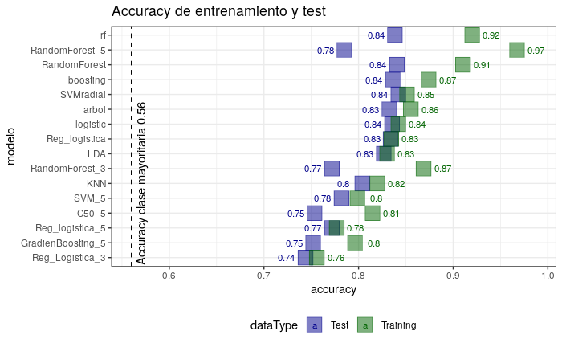

```r
# gg_aux =
ggplot(data = metricas_predicciones,
       aes(x = reorder(object, accuracy), y = accuracy,
           color = dataType, label = round(accuracy, 2))) +
  geom_point(size = 7, shape = 22, alpha = 0.5, aes(fill = dataType)) +
  # geom_point(size = 5, shape = 22) +
  # geom_bar(stat = "identity", position = "dodge2", aes(fill = NA) ) +
  scale_color_manual(values = c("darkblue", "darkgreen")) +
  scale_fill_manual(values = c("darkblue", "darkgreen")) +
  # geom_text(color = "black", size = 3 ) +
  geom_text(size = 3, position = position_nudge(y = if_else(metricas_predicciones$dataType == "Test", -0.02, 0.02)), mapping = aes(label= round(accuracy,2))) +
  # geom_label(size = 3, position = position_nudge(y = if_else(metricas_predicciones$dataType == "Test", -0.05, 0.05)), mapping = aes(label= round(accuracy,2))) +
  # scale_y_continuous(limits = c(0, 1)) +
  # Accuracy basal
  geom_hline(yintercept = 0.56, linetype = "dashed") +
  annotate(geom = "text", y = 0.57, x = 6, label = "Accuracy clase mayoritaria 0.56", angle = 90) +
  coord_flip() +
  labs(title = "Accuracy de entrenamiento y test",
       x = "modelo") +
  theme_bw() +
  theme(legend.position = "bottom")
```

```r
# agrego los labels (los valores son relativos a el punto en cuestion)
# gg_aux +
#     geom_label(size = 3,  nudge_y = if_else(gg_aux$data$dataType == "Test", -0.05, 0.05 ), aes(label= round(accuracy,2)))
```